# SP22: Machine Learning for Signal Processing - Assignment 1

## Name : Akhila Sakiramolla (asakiram@iu.edu)

## UID : 2000886005

## Importing required libraries

```python
from scipy.io import wavfile
import numpy as np
import pandas as pd
from numpy import linalg as la
import random
import math
import scipy
from scipy import signal
import IPython.display as ipd
import matplotlib.pyplot as plt
from scipy.stats import multivariate_normal
# To execute a cell line by line
from IPython.core.interactiveshell import InteractiveShell
InteractiveShell.ast_node_interactivity = "all"
```

## P1: De-beeper

```python
# Loading audio file

samplerate, data = wavfile.read(r'C:\Users\Akhila Sakiramolla\Desktop\My Files\IUB\Semester 2\MLSP\Assignment2\x.wav')
print("Sample rate :",samplerate)
print("Data shape :",data.shape)
print("Data :", data)

# Normalizing the data
data = data/la.norm(data)
print("Data :", data)
```

```
Sample rate : 16000
Data shape : (63488,)
Data : [466 660 465 ...   8  10   7]
Data : [2.05352976e-03 2.90843271e-03 2.04912304e-03 ... 3.52537298e-05
 4.40671622e-05 3.08470136e-05]
```

The discrete Fourier transform is a complex-valued function of frequency that turns a finite sequence of equally-spaced samples of a function into a same-length sequence of equally-spaced samples of the discrete-time Fourier transform.

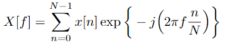

```python
# Function to calculate DFT matrix

def DFTmatrix(N):
  DFT = np.empty((N,N), dtype = complex)
  for n in range(0,N):
      for f in range(0,N):
          DFT[n][f] = np.exp(-1j*(2*np.pi*n*f/N))
  return DFT
```

```python
# Frame size

N = 1600

# Calculating DFT matrix of N = 1600
F =  DFTmatrix(N)
print("Shape of DFT Matrix :", F.shape)
```

```
Shape of DFT Matrix : (1600, 1600)
```

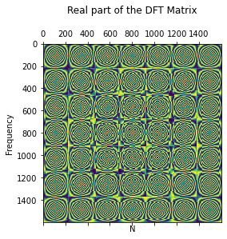

```python
# Real part of the DFT matrix

plt.figure(figsize=[12,8])
plt.matshow(F.real)
plt.title('Real part of the DFT Matrix\n');
plt.xlabel('N');
plt.ylabel('Frequency');
plt.show()
```

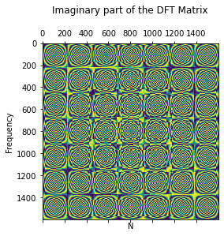

```python
# Imaginary part of the DFT matrix

plt.figure(figsize=[12,8])
plt.matshow(F.imag)
plt.title('Imaginary part of the DFT Matrix\n')
plt.xlabel('N')
plt.ylabel('Frequency')
plt.show()
```

Hanning is a fast fourier transform window function for signal or image filtering. More realistic results can be produced by processing data with Hanning before applying FFT. Hanning's window is essentially the first half of a cosine—that is, only positive cosine values are included. Hanning returns a vector of the same length as col when used with only the col parameter. The vector has zeros at both ends and rises to a peak in the middle (just as a cosine goes up and then comes back down to zero). Hanning's finding is determined by the following equation in one dimension:

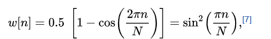

```python
# Function to calculate Hanning window

def hannWindow(N):
  return 0.5 - (0.5 * np.cos(2 * np.pi / N *np.arange(N)))
```

```python
# Creation of data matrix

X = []
for i in range(0, (data.shape[0]//N)*N, N//2):
  col = np.multiply(data[i:i+N], hannWindow(N))
  X.append(col)
```

```python
# Converting X to array and transposing it

X = np.array(X)
print("Shape of X :",X.shape)

X = X.T
print("Shape of X :",X.shape)
```

```
Shape of X : (78, 1600)
Shape of X : (1600, 78)
```

```python
# Applying DFT matrix to data matrix X

FX = np.dot(F, X)
print("Shape of FX :", FX.shape)
```

```
Shape of FX : (1600, 78)
```

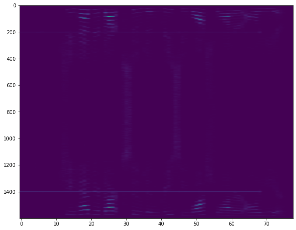

```python
# Plotting spectrogram by taking absolute values of FX

plt.figure(figsize=[10,8])
plt.imshow(np.abs(FX), aspect = 'auto')
```

From the spectrogram plot, we observe that there is noise at 200, 1400 rows.

```python
# Debeeping the audio by converting the noise data to zero

FX[1398:1402] = np.zeros(len(FX[1400]))
FX[198:202] = np.zeros(len(FX[200]))
```

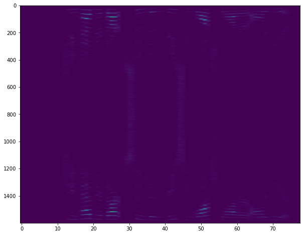

```python
# Plotting spectrogram by taking absolute values of FX

plt.figure(figsize=[10,8])
plt.imshow(np.abs(FX), aspect = 'auto')
```

After removing the noise, by making the values zero, from the spectrogram plots, we observe that the noise has been cleared and the audio is debeedped.

Equation to calculate inverse DFT matrix:

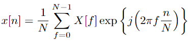

```python
# Function to calculate Inverse DFT matrix

def inverseDFTMatrix(N):
    Inv_DFT = np.empty((N,N), dtype = complex)
    for n in range(0,N):
      for f in range(0,N):
        Inv_DFT[n][f] = np.exp(1j*(2*np.pi*n*f/N))
    return Inv_DFT/N
```

```python
# Creating inverse DFT matrix of FX

Inv_DFT = inverseDFTMatrix(N)

# Applying inverse DFT matrix to spectrogram free from the beep tones to get back to the recovered version of your data matrix
X_hat = np.dot(Inv_DFT, FX)
print("Shape of X_hat :", X_hat.shape)
X_hat = X_hat.real.T
print("Shape of X_hat :", X_hat.shape)
```

```
Shape of X_hat : (1600, 78)
Shape of X_hat : (78, 1600)
```

```python
# Recovering audio data

X_recovered = []
for i in range(X_hat.shape[0]-1):
  X_recovered.extend(X_hat[i][N//2:N] + X_hat[i+1][0:N//2])

X_recovered = np.array(X_recovered)
print("Shape of recovered data matrix:", X_recovered.shape)
```

```
Shape of recovered data matrix: (61600,)
```

### Unclean audio signal

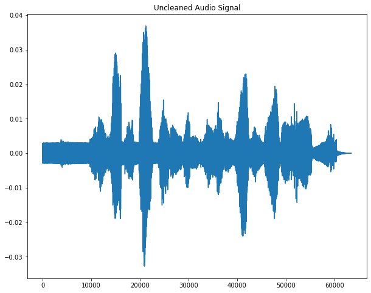

```python
# Plotting uncleaned audio signal

plt.figure(figsize=[10,8])
plt.plot(data)
plt.title('Uncleaned Audio Signal')
```

```python
# Uncleaned audio

ipd.Audio(r'C:\Users\Akhila Sakiramolla\Desktop\My Files\IUB\Semester 2\MLSP\Assignment2\x.wav')
```

[interactive chart not shown]

### Cleaned Audio signal

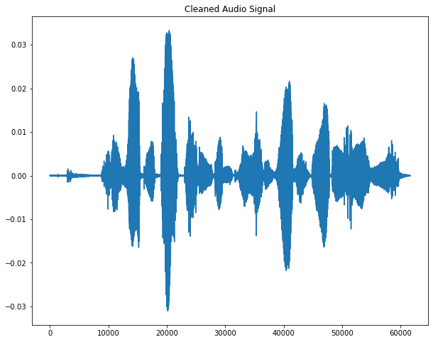

```python
# Plotting cleaned audio signal

plt.figure(figsize=[10,8])
plt.plot(X_recovered)
plt.title('Cleaned Audio Signal')
```

```python
# Cleaned audio signal

ipd.Audio(X_recovered, rate = samplerate)
```

[interactive chart not shown]

## P2: Parallax

```python
# Loading december data

dec_load = scipy.io.loadmat(r'C:\Users\Akhila Sakiramolla\Desktop\My Files\IUB\Semester 2\MLSP\Assignment2\december.mat')
dec_data = dec_load['december']
dec_data = np.int64(dec_data)
print("Shape of december data: ",dec_data.shape)
```

```
Shape of december data:  (2700, 2)
```

```python
# Loading december data

june_load = scipy.io.loadmat(r'C:\Users\Akhila Sakiramolla\Desktop\My Files\IUB\Semester 2\MLSP\Assignment2\june.mat')
june_data = june_load['june']
june_data = np.int64(june_data)
print("Shape of june data: ",dec_data.shape)
```

```
Shape of june data:  (2700, 2)
```

```
Shape of june data:  (2700,)
```

|  | disparity |
| --- | --- |
| 0 | 40 |
| 1 | 42 |
| 2 | 42 |
| 3 | 52 |
| 4 | 32 |

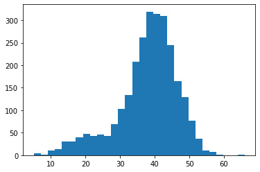

```python
# Calculating disparity between june and december data

disparity = dec_data[:, 0] - june_data[:, 0]
print("Shape of june data: ",disparity.shape)

# Converting array to dataframe
disparity_df = pd.DataFrame(disparity, columns = ['disparity'])
disparity_df.head()

# Plotting histogram of the disparity data
plt.hist(disparity, bins = 30)
```

From the histogram, we observe that there are two distributions.

### K-Means algorithm

```python
# Fucntion to generate random centroids

def calc_centroid(df,k):
  rand_values = random.sample(range(0, len(df)), k) # Selecting k random indices from the dataset
  centroids = []
  for i in rand_values:
      centroids.append(df.loc[i])  # Getting all the column values for a particular centroid index we have chosen
  centroids = np.array(centroids)
  return centroids
```

```python
# Function to calculate distance between every data point and assigned centroid

def calc_distance(a, b):
  distance = np.linalg.norm(a-b)
  return distance
```

```python
# Function to find the nearest centroid for each data point

def calc_nearestCentroid(df_array,centroids):
    nearest_centroid = []
    for i in df_array:
        distance=[]
        for j in centroids:
            distance.append(calc_distance(i, j))
        nearest_centroid.append(np.argmin(distance))
    return nearest_centroid
```

```python
# Function to calculate new centroids to all points which are nearer than the previous centroids

def calc_newCentroids(nearest_centroids, df_array):
    new_centroids = []
    clusters = []
    new_df = pd.concat([pd.DataFrame(df_array), pd.DataFrame(nearest_centroids, columns=['cluster'])],axis=1)
    for i in set(new_df['cluster']):
        current_cluster = new_df[new_df['cluster'] == i][new_df.columns[:-1]]
        cluster_mean = current_cluster.mean(axis=0)
        new_centroids.append(cluster_mean)
    clusters = np.unique(new_df['cluster'])
    label = new_df['cluster']
    return new_centroids,clusters,label,new_df
```

### Implementation of K-means algorithm

```python
# Initialising random centroids

centroids = calc_centroid(disparity_df,2)
centroids

# Implementing K-means algorithm on disparity data
for i in range(10):
  nearest_centroids = calc_nearestCentroid(disparity,centroids)
  new_centroids,clusters,label,new_df = calc_newCentroids(nearest_centroids, disparity)
```

```
array([[37],
       [24]], dtype=int64)
```

```python
print("The new centroids are : ", new_centroids)

new_df.rename(columns={new_df.columns[0]: "disparity" }, inplace = True)
```

```
The new centroids are :  [0    40.738576
dtype: float64, 0    22.443396
dtype: float64]
```

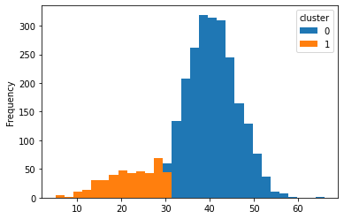

```python
# Plotting histogram of the disparity data with labels

new_df.pivot(columns='cluster', values='disparity').plot.hist(bins = 30)
plt.show()
```

From the histogram, we observe that there are two clusters as expected earlier.

## P3: GMM for Parallax

### Expectation Maximiztion algorithm

The expectation–maximization (EM) algorithm is an iterative approach for determining (local) maximum likelihood or maximum a posteriori (MAP) parameter estimates in statistical models that rely on unobserved latent variables. The EM iteration alternates between an expectation (E) step that constructs a function for the expected log-likelihood evaluated using the current estimate for the parameters and a maximization (M) phase that computes parameters that maximize the expected log-likelihood discovered on the E step. In the next E phase, these parameter estimates are utilized to determine the distribution of the latent variables.

```python
# Function to Initiliaze the mean, variance and prior

def initializeData(df,k):
  mean_mat = [41, 23]
  var_mat = [random.randint(0, 60), random.randint(0, 60)]
  prior_prob = 1/k
  prior_prob_mat = [prior_prob]*k

  return mean_mat, var_mat, prior_prob_mat
```

E - step : calculate posterior probabilities

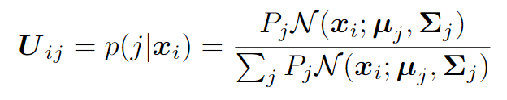

```python
# Function to calculate posterior probability - E step

def expectation(df,k,mean,var,prior_prob_mat):
  n = df.shape[0]
  pdf = [0]*k
  wts = [0]*k
  total_wts = [0]*n
  for i in range(k):
    pdf[i] = multivariate_normal.pdf(df, mean=mean[i], cov=var[i],allow_singular=True)
    wts[i] = pdf[i]*prior_prob_mat[i]
    total_wts += wts[i]

  post_prob = [0]*k
  total_post_prob = [0]*n
  for i in range(k):
    post_prob[i] = wts[i]/total_wts
    total_post_prob += post_prob[i]

  return post_prob
```

M - step : to update mean, variance and prior parameteres

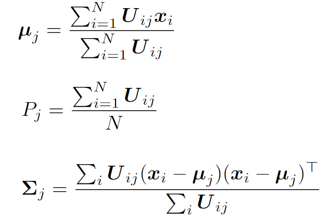

```python
# Function to re-estimate the mean, variance and prior - M step

def maximization(k, post_prob, df):
  d = df.shape[1]
  mean_updated = []
  var_updated = []
  prior_updated = []
  for i in range(k):
    mean_updated.append(np.divide(np.dot(post_prob[i], df), sum(post_prob[i])))
    var_updated.append(np.dot(post_prob[i], (df.to_numpy() - mean_updated[i])**2)/ sum(post_prob[i]))
    prior_updated.append(sum(post_prob[i])/df.shape[0])

  return mean_updated, var_updated, prior_updated
```

```python
# Expectation maximization algorithm

def expectationMaximization(X,k):
  eps = 0.0001
  e = 1000
  error_list = []
  i = 0
  mean,var,prior_prob = initializeData(X,k)
  while e > eps:
    post_prob = expectation(X,k,mean,var,prior_prob)
    mean_updated, var_updated, prior_updated = maximization(k,post_prob, X)

    e = np.linalg.norm(mean_updated-np.array(mean))**2

    if e <= eps:
      error_list.append(e)
      break
    mean = mean_updated
    i += 1

  return post_prob, mean_updated,var_updated, prior_updated, error_list,i
```

### Implementation of Expectation Maximiztion algorithm

```python
for i in range(20):
  post_prob, mean_updated, cov_updated, prior_updated, error_list, iter_count = expectationMaximization(disparity_df, k = 2)


print("Estimated Means :", np.round(mean_updated,2))
print("Estimated Variance :", np.round(cov_updated,2))
print("Estimated Prior weights :", np.round(prior_updated,2))
```

```
Estimated Means : [[40.32]
 [20.93]]
Estimated Variance : [[31.78]
 [29.76]]
Estimated Prior weights : [0.87 0.13]
```

I prefer EM algorithm over K-means due to the following reasons:

1. K-means deterministically assigns a data point to one particular cluster on convergence which is hard clustering but in reality there may be overlapping between the cluster, where as EM assigns probabilities of belonging to different clusters to each data point which is soft clustering.
2. K-means is based on the L2 norm, whereas EM is based on the Expectation, which is the probability of a point belonging to a certain cluster. K-means ignores variance and places a circle at the center of each cluster, with a radius determined by the cluster's farthest point. When the data is circular, this method works well. It does not work effectively, though, when data takes on a different shapes. Whereas, even exceedingly oblong clusters can be handled by Gaussian mixture models.